# Projet Série Temporelle

### SARIMA Auto

On va essayer de voir ce qu’on peut obtenir avec un SARIMA automatique :

```r
fitAuto=auto.arima(elec_train,lambda = "auto")
summary(fitAuto)
```

```
Series: elec_train
ARIMA(5,0,1)(0,1,0)[96]
Box Cox transformation: lambda= 0.443743

Coefficients:
         ar1      ar2     ar3      ar4     ar5      ma1
      0.9335  -0.0531  0.0256  -0.2543  0.1586  -0.1900
s.e.  0.0996   0.0747  0.0223   0.0208  0.0195   0.1007

sigma^2 = 0.2459:  log likelihood = -3024.7
AIC=6063.4   AICc=6063.43   BIC=6107.83

Training set error measures:
                     ME     RMSE      MAE        MPE     MAPE      MASE         ACF1
Training set -0.0871035 10.08052 5.942022 -0.1357493 2.701743 0.7281771 0.0007368769
```

```r
prev= forecast(fitAuto)
cat("RMSE", sqrt(mean(elec_test-prev$mean)^2))
```

```
RMSE 9.129775
```

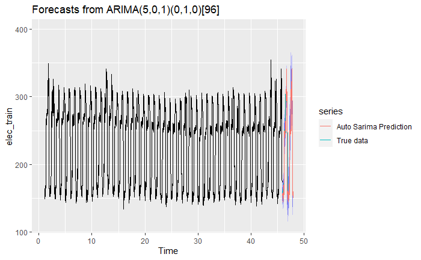

```r
autoplot(prev) + autolayer(elec_test, series="True data")+ autolayer(prev$mean, series="Auto Sarima Prediction")
```

Les résulats de ce modèle sont inférieur à ce que l’on a trouvé auparavant

## NEURAL NETWORK

On essaye de faire une prédiction avec un réseau de neurones

```r
NNfit=nnetar(elec_train)
summary(NNfit)
```

```
          Length Class        Mode
x         4315   ts           numeric
m            1   -none-       numeric
p            1   -none-       numeric
P            1   -none-       numeric
scalex       2   -none-       list
size         1   -none-       numeric
subset    4315   -none-       numeric
model       20   nnetarmodels list
nnetargs     0   -none-       list
fitted    4315   ts           numeric
residuals 4315   ts           numeric
lags        12   -none-       numeric
series       1   -none-       character
method       1   -none-       character
call         2   -none-       call
```

```r
prevNNfit= forecast(NNfit)
cat("RMSE", sqrt(mean(elec_test-prevNNfit$mean)^2))
```

```
RMSE 8.360124
```

Le résultat n’est pas assez performant, comparé aux RMSE du SARIMA

## Holt-Winters

On essaye de faire une prédiction avec un Holt-Winters.

```r
fitHW= HoltWinters(elec_train)
summary(fitHW)
```

```
             Length Class  Mode
fitted       16876  mts    numeric
x             4315  ts     numeric
alpha            1  -none- numeric
beta             1  -none- numeric
gamma            1  -none- numeric
coefficients    98  -none- numeric
seasonal         1  -none- character
SSE              1  -none- numeric
call             2  -none- call
```

```r
prevfitHW= forecast(fitHW)
cat("RMSE", sqrt(mean(elec_test-prevfitHW$mean)^2))
```

```
RMSE 9.046928
```

De même pour cette méthode, le résultat n’est pas assez performant

## Choix Modèle

Même si le modèle SARIMA(3,0,3)(0,1,1)[96] n’est pas le modèle qui a capté le plus d’informations.  
C’est le modèle avec le RMSE le plus bas : 3.982057  
Son bruit balnc n’est pas pris en compte avec une p-value = 3.682e-09

### Export des prédictions

#### Pour la prévision sans l’utilisation de la température extérieure

```r
fit303F=Arima(elec_prev, order=c(3,0,3), seasonal=c(0,1,1))#96
prevFinal = forecast(fit303F, h=96)
```

```r
write.xlsx(as.data.frame(prevFinal$mean), "exportPower.xlsx")
```

# Utilisation de la variable Temperature

On va d’abord essayer de voir si il y a correlation entre les variables Temperature et Power

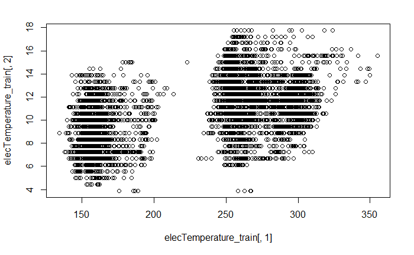

```r
plot(elecTemperature_train[,1], y=elecTemperature_train[,2])
```

```r
cor(elecTemperature_train)
```

```
           Power (kW) Temp (C°)
Power (kW)  1.0000000 0.4722473
Temp (C°)   0.4722473 1.0000000
```

Nous obtenons une valeur de 0.472  
Les variables ne semblent pas vraiment corrélées.

## Prévisions

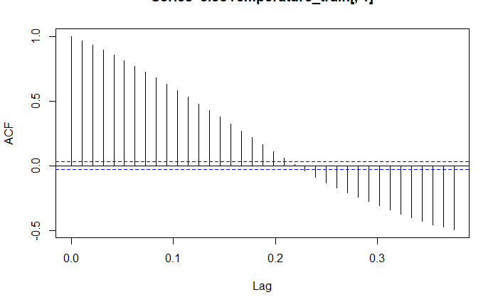

```r
tmp=acf(elecTemperature_train[,1],type="cor",plot = FALSE)
plot(tmp)
```

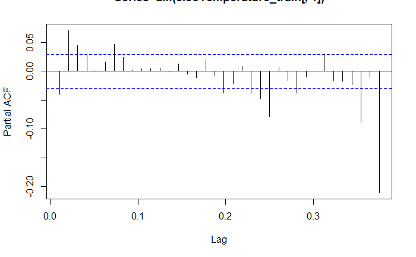

```r
diffpacf=pacf(diff(elecTemperature_train[,1]),type="cor",plot = FALSE)
plot(diffpacf)
```

On remarque à nouveau une saisonnalité et avec le PACF on a un pic du lag à 2

```r
cat("RMSE", sqrt(mean(elecTemperature_test[,1]-prevfit200Temp$mean)^2))
```

[output not shown]

```
RMSE 3.261178
```

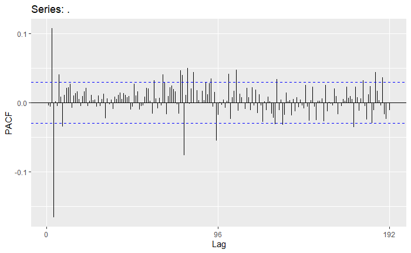

```r
fit200Temp %>% residuals() %>% ggPacf()
```

Grâce au PACF, on voit un pic au lag 3, on va améliorer le modèle

```r
fit400Temp=Arima(elecTemperature_train[,1], order=c(4,0,0), seasonal=c(0,1,1), xreg = elecTemperature_train[,2])#96
summary(fit400Temp)
```

```
Series: elecTemperature_train[, 1]
Regression with ARIMA(4,0,0)(0,1,1)[96] errors

Coefficients:
         ar1     ar2     ar3      ar4     sma1    xreg
      0.6792  0.0959  0.1244  -0.1493  -0.8631  0.7070
s.e.  0.0151  0.0182  0.0182   0.0152   0.0084  0.2005

sigma^2 = 64.55:  log likelihood = -15176.92
AIC=30367.84   AICc=30367.87   BIC=30412.43

Training set error measures:
                     ME    RMSE      MAE        MPE     MAPE    MASE       ACF1
Training set -0.4237798 7.94078 4.791944 -0.2784618 2.180156 0.57578 0.01656161
```

```r
prevfit400Temp= forecast(fit400Temp, xreg=elecTemperature_test[,2])
cat("RMSE", sqrt(mean(elecTemperature_test[,1]-prevfit400Temp$mean)^2))
```

```
RMSE 3.380815
```

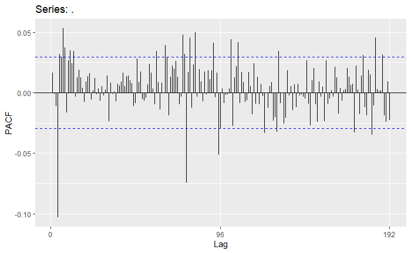

```r
fit400Temp %>% residuals() %>% ggPacf()
```

On observe toujours un pic sur le lag 4 on va essayer d’en prendre un autre pic ici avec le lag 7

```r
fit700Temp=Arima(elecTemperature_train[,1], order=c(7,0,0), seasonal=c(0,1,1), xreg = elecTemperature_train[,2])#96
summary(fit700Temp)
```

```
Series: elecTemperature_train[, 1]
Regression with ARIMA(7,0,0)(0,1,1)[96] errors

Coefficients:
         ar1     ar2     ar3      ar4     ar5     ar6     ar7     sma1    xreg
      0.7136  0.0821  0.0913  -0.2222  0.0803  0.0347  0.0243  -0.8614  0.5014
s.e.  0.0154  0.0189  0.0189   0.0187  0.0191  0.0191  0.0157   0.0087  0.2253

sigma^2 = 61.29:  log likelihood = -14729.48
AIC=29478.96   AICc=29479.01   BIC=29542.43

Training set error measures:
                     ME     RMSE      MAE        MPE     MAPE      MASE         ACF1
Training set -0.3477228 7.733109 4.693706 -0.2438774 2.143879 0.5753418 -0.001330753
```

```r
prevfit700Temp= forecast(fit700Temp, xreg=elecTemperature_test[,2])
cat("RMSE", sqrt(mean(elecTemperature_test[,1]-prevfit700Temp$mean)^2))
```

```
RMSE 4.657614
```

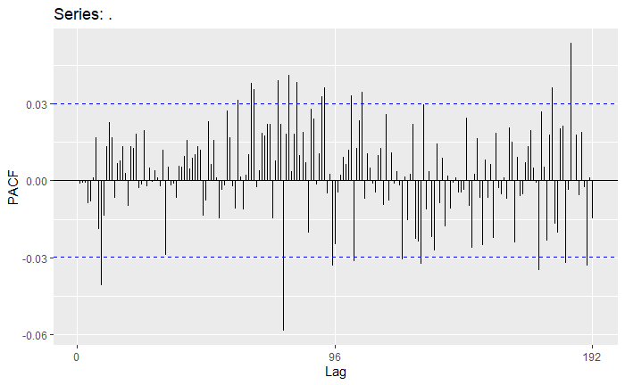

```r
fit700Temp %>% residuals() %>% ggPacf()
```

On observe un pic sur le lag 9 on va essayer d’améliorer le modèle

```r
fit900Temp=Arima(elecTemperature_train[,1], order=c(9,0,0), seasonal=c(0,1,1), xreg = elecTemperature_train[,2])#96

summary(fit900Temp)
```

```
Series: elecTemperature_train[, 1]
Regression with ARIMA(9,0,0)(0,1,1)[96] errors

Coefficients:
         ar1     ar2     ar3      ar4    ar5     ar6     ar7      ar8      ar9     sma1    xreg
      0.6944  0.0838  0.1185  -0.2455  0.105  0.0108  0.0452  -0.0136  -0.0066  -0.8659  0.6058
s.e.  0.0152  0.0186  0.0186   0.0187  0.019  0.0186  0.0186   0.0185   0.0153   0.0085  0.2199

sigma^2 = 63.38:  log likelihood = -15136
AIC=30296.01   AICc=30296.08   BIC=30372.45

Training set error measures:
                     ME     RMSE      MAE        MPE     MAPE      MASE         ACF1
Training set -0.3546927 7.864058 4.771477 -0.2482636 2.169055 0.5733208 -0.001483967
```

```r
prevfit900Temp= forecast(fit900Temp, xreg=elecTemperature_test[,2])
cat("RMSE", sqrt(mean(elecTemperature_test[,1]-prevfit900Temp$mean)^2))
```

```
RMSE 3.143429
```

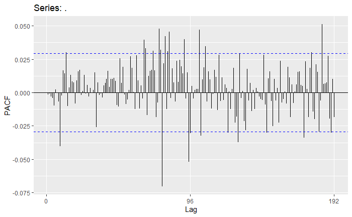

```r
fit900Temp %>% residuals() %>% ggPacf()
```

On observe un pic sur le lag 8 on va essayer d’améliorer le modèle

```r
fit800Temp=Arima(elecTemperature_train[,1], order=c(8,0,0), seasonal=c(0,1,1), xreg = elecTemperature_train[,2])#96
summary(fit800Temp)
```

```
Series: elecTemperature_train[, 1]
Regression with ARIMA(8,0,0)(0,1,1)[96] errors

Coefficients:
         ar1     ar2     ar3      ar4     ar5     ar6     ar7      ar8     sma1    xreg
      0.6946  0.0835  0.1184  -0.2461  0.1066  0.0100  0.0447  -0.0181  -0.8660  0.5986
s.e.  0.0152  0.0185  0.0186   0.0186  0.0186  0.0186  0.0185   0.0153   0.0085  0.2200

sigma^2 = 63.37:  log likelihood = -15136.1
AIC=30294.2   AICc=30294.26   BIC=30364.26

Training set error measures:
                     ME     RMSE      MAE        MPE     MAPE      MASE        ACF1
Training set -0.3522732 7.864132 4.770965 -0.2472987 2.168549 0.5732593 -0.00192004
```

```r
prevfit800Temp= forecast(fit800Temp, xreg=elecTemperature_test[,2])
cat("RMSE", sqrt(mean(elecTemperature_test[,1]-prevfit800Temp$mean)^2))
```

```
RMSE 3.137962
```

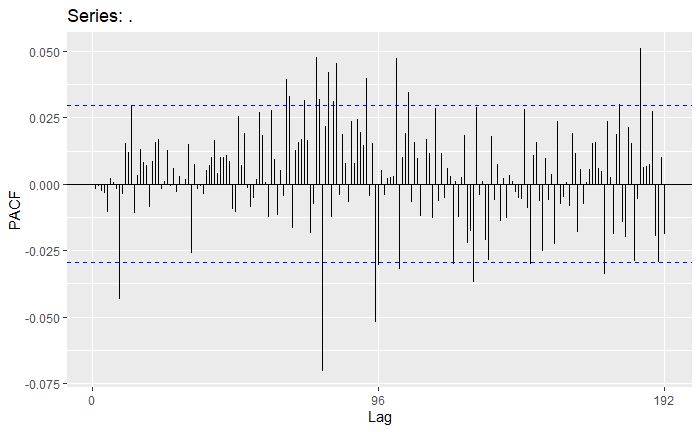

```r
fit800Temp %>% residuals() %>% ggPacf()
```

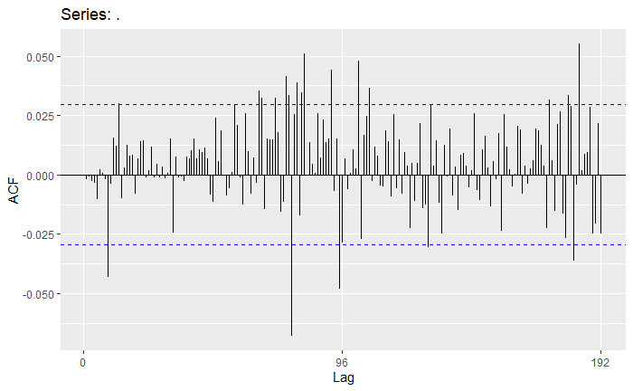

```r
fit800Temp %>% residuals() %>% ggAcf()
```

On arrive plus à stabiliser les pic des lag, cela nécessite trop de performances.

## NEURAL NETWORK

On essaye de faire une prédiction avec un réseau de neurones.

```r
NNfitTemp=nnetar(elecTemperature_train[,1], xreg = elecTemperature_train[,2])
summary(NNfitTemp)
```

```
          Length Class        Mode
x         4411   ts           numeric
m            1   -none-       numeric
p            1   -none-       numeric
P            1   -none-       numeric
scalex       2   -none-       list
scalexreg    2   -none-       list
size         1   -none-       numeric
xreg      4411   -none-       numeric
subset    4411   -none-       numeric
model       20   nnetarmodels list
nnetargs     0   -none-       list
fitted    4411   ts           numeric
residuals 4411   ts           numeric
lags        17   -none-       numeric
series       1   -none-       character
method       1   -none-       character
call         3   -none-       call
```

```r
prevNNfitTemp= forecast(NNfitTemp, xreg=elecTemperature_test[,2])
cat("RMSE", sqrt(mean(elecTemperature_test[,1]-prevNNfitTemp$mean)^2))
```

```
RMSE 1.208937
```

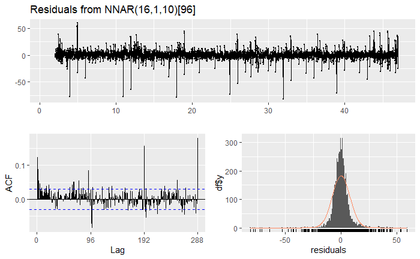

```r
checkresiduals(NNfitTemp)
```

Le résultat est très satisfesant comparé aux RMSE du SARIMA

### Pour la prévision avec l’utilisation de la température extérieure

Les prédictions semblent vraiment similaires avec ou sans la variable température, on a aperçu une petite différence de performances entre les modèles.  
Le modèle utilisant un réseau de neurone s’est démarqué avec un RMSE bizarrement bas de 1.208937.

## Exportation des résultats

```r
fitFinaltemp = nnetar(elecTemperature_prev[1:4507,1], xreg = elecTemperature_prev[1:4507,2])
prevFinalTemp= forecast(fitFinaltemp, xreg=elecTemperature_prev[4508:4603,2])
write.xlsx(as.data.frame(prevFinalTemp$mean), "exportPowerTemp.xlsx")
```